# DM de Series Temporelles

# Exercice 1 : Actions d’Intel

## Introduction

Dans cette partie, nous allons modéliser la série $rtn$ (dans le fichier m-intc7303.txt). Cette série financière désigne les variations relatives mensuelles de l’action Intel entre janvier 1973 et décembre 2003. La série $rtn$ semble avoir des effets saisonnaliers qui croissent avec le temps, on donc un modèle multiplicatif. Pour rendre la série additive, nous allons utiliser une transformation logarithmique. Ainsi on obtient le rendement mensuel de ce cours d’action $logrtnt$ :

$$\forall t \in [|1;372|] \quad logrtn_t = ln (1 + rtn_t)$$

[interactive chart not shown]

La représentation graphique du rendement mensuel du cours d’actions intel ($logrtnt$) ne présente pas de tendance, on remarque que les valeurs de la série fluctuent autour de 0. On remarque aussi 2 périodes de grandes volatilités. Ces volatililtés sont dûes à des crises économiques qui ont provoqué une euphorie sur les marchés financiers. En effet la 1ère période de volatilité entre 1973 et 1974 résulte de la crise pétolière de 1973 encore appelé [premier choc prétolier](https://fr.wikipedia.org/wiki/Premier_choc_p%C3%A9trolier). La seconde période de volatilité apparu dans les années 2000 s’explique par la grande [récession du début des années 2000](https://fr.wikipedia.org/wiki/R%C3%A9cession_du_d%C3%A9but_des_ann%C3%A9es_2000). Cette crise financière a touché toutes les grandes économies du mondes et provoqué un effondrement du marché boursier. Ainsi, les indices comme le NASDAQ et le DOWJONES ont atteint niveau de décroissance record.

## 1. Teste de blancheur de $logrtnt$ et $logrtnt^2$

En rappelle, il existe trois notions de bruit blancs à savoir le bruit blanc fort, le bruit blanc gaussien et le bruit blanc faible. Nous nous intéressons spécialement à cette notion de bruit blanc faible.

Un processus $Y_t$ est bruit blanc (faible) si :

$\forall t \in \mathbb{Z} :$  
1. $E(Y_t)$ = 0  
2. $E(Y_t^2) = \sigma^2$  
3 $Cov(Y_t, Y_{t'}) = 0$

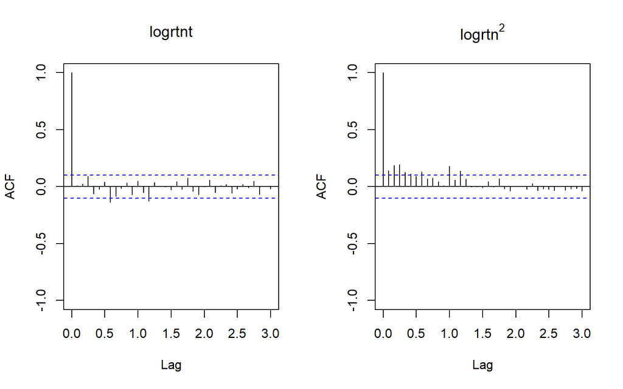

L’ACF de $logrtnt^2$ présente quelques pics significatifs. $logrtnt^2$ ne semble pas être donc un bruit blanc. Avec des p-valeurs < 5% pour différentes valeurs de retard considérées, le test de “Ljung-Box” nous permet de rejetter l’hypothèse que $logrtnt^2$ est un bruit blanc.

**Conclusion partielle :** Le processus $logrtn$ est un bruit blanc tant dis que $logrtn^2$ ne l’est pas. A condition que $logrtn^2$ soit stationnaire, on peut modéliser $logrtn$ par un processus GARCH en identifiant un ARMA sur le processus $logrtn^2$.

```
     Retard p-value
[1,]      6   0.487
[2,]     12   0.112
[3,]     18   0.100
[4,]     24   0.137
[5,]     30   0.230
[6,]     36   0.366
```

```
     Retard p-value
[1,]      6       0
[2,]     12       0
[3,]     18       0
[4,]     24       0
[5,]     30       0
[6,]     36       0
```

## 2. Identifier un(des) modèle(s) ARMA sur la série $logrtn^2$

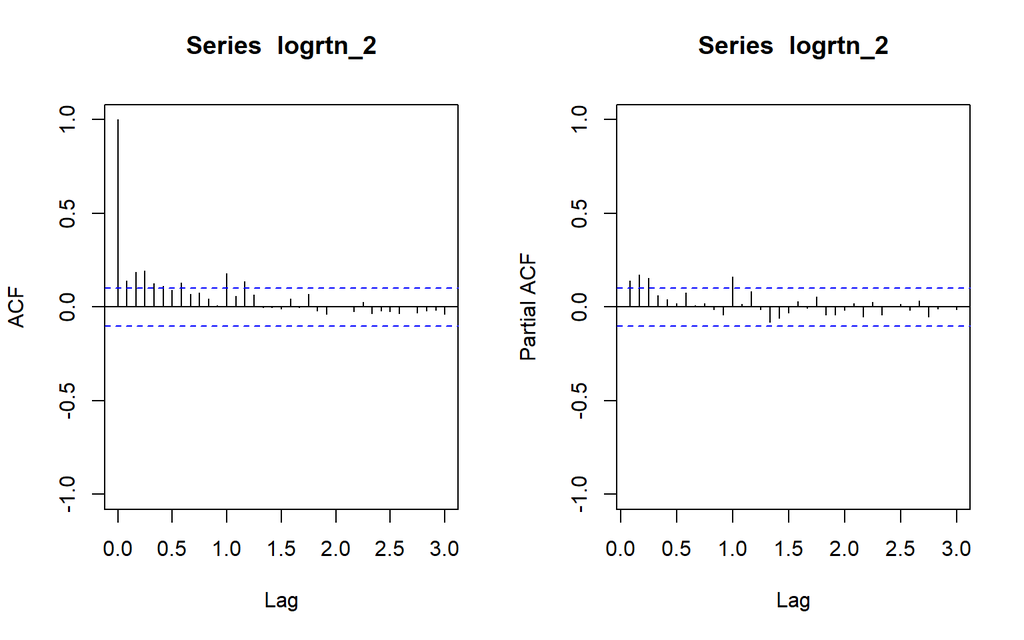

L’ ACF présente de faibles autocorélations décroissantes vers 0. Le processus semble stationnaire. Pour s’en convaincre, nous allons effectuer le test augmenté de Dickey Fuller (ADF) (cf Annexe 2).

```
    Augmented Dickey-Fuller Test

data:  logrtn_2
Dickey-Fuller = -4.9388, Lag order = 7, p-value = 0.01
alternative hypothesis: stationary
```

La p-value = 0.01 < 5%, on rejette l’hypothèse de présence de racine unitaire. On peut donc dire que $logrtnt^2$ est stationnaire.

Pour identifier l’ordre $p$ et $q$, de notre $ARMA(p,q)$ regardons l’ACF et le PACF.

```
             ar1      ar2      ar3      ma1       ma2       ma3 intercept
t.stat -0.107043 1.900548 0.435365 0.197410 -1.625976 -0.259290  4.404991
p.val   0.914755 0.057361 0.663297 0.843506  0.103955  0.795412  0.000011
```

```
            ar1      ar2       ma1      ma2 intercept
t.stat 1.707821 0.084026 -1.563178 0.096393  4.410712
p.val  0.087670 0.933036  0.118011 0.923208  0.000010
```

[output not shown]

```
            ar1       ma1      ma2 intercept
t.stat 11.54139 -8.885293 1.188892  4.436490
p.val   0.00000  0.000000 0.234482  0.000009
```

```
            ar1       ma1 intercept
t.stat 19.46636 -11.63702  4.159371
p.val   0.00000   0.00000  0.000032
```

Les résultats de ces tests indiquent que seul le processus ARMA(1,1) a tous ses paramètres significatifs (avec des p-valeurs<5%).

**Conclusions** : On identifie donc le processus ARMA(1,1) pour le processus $logrtn^2$.

$$(I - \phi_1 B) Y_t^2 = (I - \theta_1 B) \epsilon_t$$

On peut donc modéliser le rendement des actions d’Intel $logrtn$ par un processus $GARCH(1,1)$.

## 3. Modéliser sous forme de processus GARCH la série $logrtn$

```
Title:
 GARCH Modelling

Call:
 garchFit(formula = ~garch(1, 1), data = logrtn, trace = FALSE)

Mean and Variance Equation:
 data ~ garch(1, 1)
<environment: 0x0000000027d6eb50>
 [data = logrtn]

Conditional Distribution:
 norm

Coefficient(s):
       mu      omega     alpha1      beta1
0.0163276  0.0010918  0.0802716  0.8553014

Std. Errors:
 based on Hessian

Error Analysis:
        Estimate  Std. Error  t value Pr(>|t|)
mu     0.0163276   0.0062624    2.607  0.00913 **
omega  0.0010918   0.0005291    2.063  0.03907 *
alpha1 0.0802716   0.0281162    2.855  0.00430 **
beta1  0.8553014   0.0461374   18.538  < 2e-16 ***
---
Signif. codes:  0 '***' 0.001 '**' 0.01 '*' 0.05 '.' 0.1 ' ' 1

Log Likelihood:
 239.5189    normalized:  0.6438681

Description:
 Fri Dec 18 01:18:45 2020 by user: sidi


Standardised Residuals Tests:
                                Statistic p-Value
 Jarque-Bera Test   R    Chi^2  156.5138  0
 Shapiro-Wilk Test  R    W      0.9676933 2.471139e-07
 Ljung-Box Test     R    Q(10)  9.805485  0.4577215
 Ljung-Box Test     R    Q(15)  16.54435  0.346824
 Ljung-Box Test     R    Q(20)  17.8005   0.6005484
 Ljung-Box Test     R^2  Q(10)  0.5130171 0.9999925
 Ljung-Box Test     R^2  Q(15)  10.24557  0.8040151
 Ljung-Box Test     R^2  Q(20)  11.77988  0.9234441
 LM Arch Test       R    TR^2   9.334459  0.6741288

Information Criterion Statistics:
      AIC       BIC       SIC      HQIC
-1.266231 -1.224092 -1.266459 -1.249496
```

Le teste de student de significativité des paramètres du processus GARCH(1,1), nous indique que tous les paramètres sont significatifs au seuil de 5%. Aussi les résidus et le carré des résidus sont bruit blanc (p_value du test de “Ljung-Box” > 5%). Enfin, le test d’hétéroscédasticité “Arch” permet de rejetter l’hypothèse de présence d’hétéroscédascité conditionnelle dans nos résidus (p_value = 0.6741288 > 5%) .

**Conclusions** : On a obtenu un modèle GARCH(1,1), avec tous les paramètres significatifs. Et aussi des résidus bruits blancs non hétéroscédastiques. Et des résidus au carré bruit blancs.

$$\forall t \in \mathbb{Z} : logrtn_t = \sigma_t \epsilon_t, \\
\sigma_t^2 = W + \alpha_1 logrtn_{t-1}^2 + \beta_1 \sigma_{t-1}^2$$

# Exercice 2 : S&P

## Introduction

Dans cette partie, nous analysons le cours mensuel de l’indice boursier S&P 500 (standard & Poors) de Novembre 1970 à Novembre 2020. Le S&P 500 est l’indice phare de la bourse américaine. Il regroupe les 500 plus grandes entreprises cotées sur le NYSE ou le NASDAQ et est donc plus représentatif de l’économie Américaine que le Dow Jones qui est seulement basé sur 30 valeurs.Il englobe tous les secteurs d’activités. Le nombre important d’actions qui le composent lui permet de couvrir une grande part du marché boursier Américain. En terme de capitalisation boursière, il représente 80% des sociétés cotées à Wall Street d’après [Yahoo finance](https://fr.finance.yahoo.com/quote/%5EGSPC/options?p=%5EGSPC).

L’intérêt de la modélisation d’une telle série est de pouvoir prévoir l’évolution du marché financier des USA. En effet, en anticipant le comportement du marché, on peut dévelloper des stratégies de trading “gagnants”.

Le S&P étant une série financière, nous allons considérer le logarithme du rendement de la série S&P définit comme suit :

$$\forall t \space \in\space \space [|1, 601|], \space logrsp = log(\frac{sp_t}{sp_{t-1}})$$

## Blancheur et stationnarité des processus

[interactive chart not shown]

La représentation graphique de l’indice S&P ne présente pas de tendance. Les valeurs de la série oscillent autour de 0. En plus l’ACF ne présente aune autocorrelation significative au seuil de 5%. Le rendement de l’indice S&P (logrsp) semble être un bruit blanc.

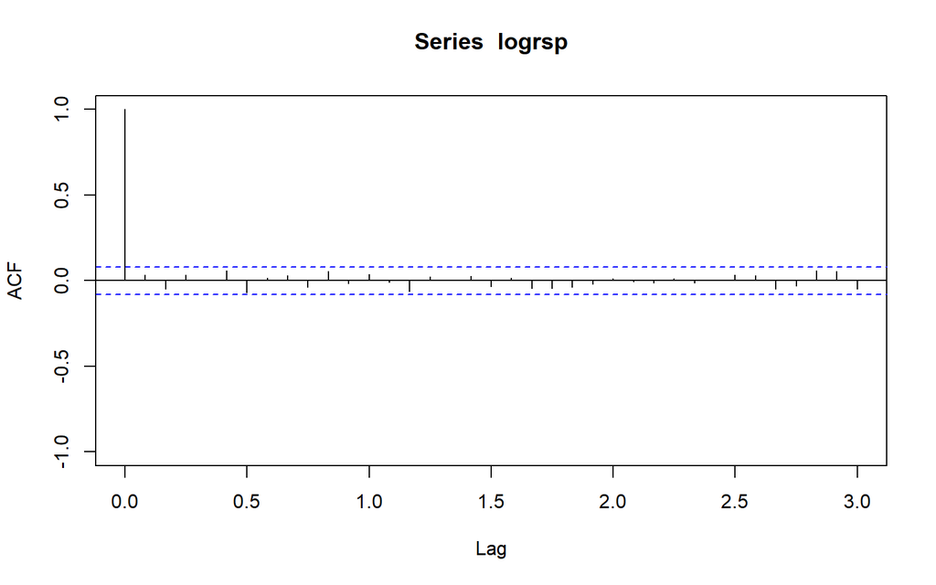

Pour nous en convaincre, nous effectuons un test de bruit blanc de “Ljung-Box”.

```
     Retard p-value
[1,]      6   0.256
[2,]     12   0.439
[3,]     18   0.576
[4,]     24   0.704
[5,]     30   0.896
[6,]     36   0.805
```

Avec des p-value > 5% pour différents retards considérés, on en déduit que le processus logrsp est un Bruit blanc.

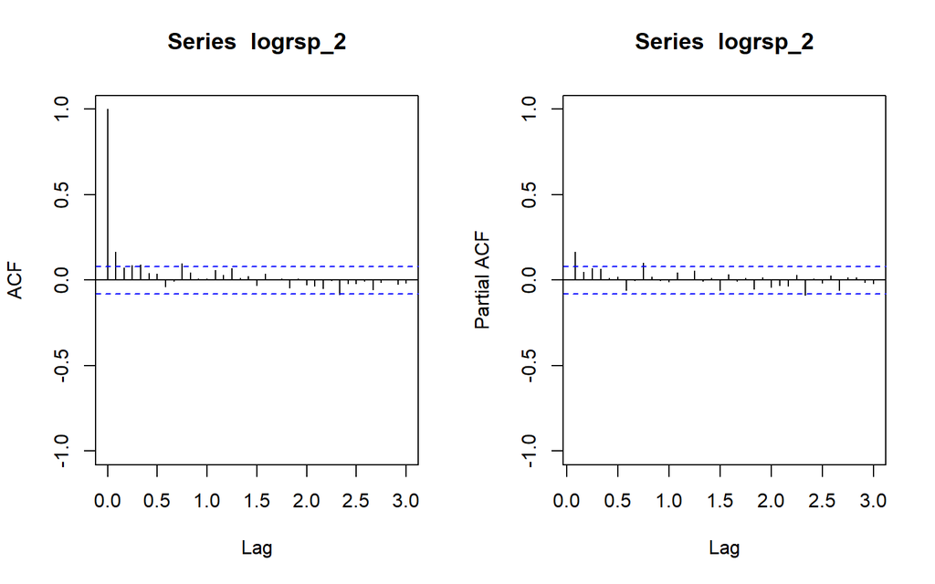

l’ACF de $logrsp^2$, présente un pic significatif. Ce processus n’est donc pas un bruit blanc. Avec des p-value < 5%, le test de “Ljung-Box” nous permet de conforter ce constat.

```
     Retard p-value
[1,]      6   0.000
[2,]     12   0.000
[3,]     18   0.000
[4,]     24   0.003
[5,]     30   0.005
[6,]     36   0.016
```

**Conclusion partielle :** Le processus $logrsp$ est un bruit blanc tandis que $logrsp^2$ ne l’est pas.  
Avec une p-valeur = 0.01, le test augmenté de Dickey-Fuller nous permet nous permet de réjeter l’hypothèse de présence de racine unitaire dans le processus $logrsp^2$. Ce processus est donc stationnaire. Ainsi on peut modéliser $logrsp$ par un processus GARCH en identifiant un ARMA sur le processus $logrsp^2$.

## Identification du Processus ARMA

Comme vu plus haut le graphe des ACF et des PACF présente un seul pic significatif. On identifie donc un processus $ARMA(1,1)$

```
[1] "Significativité des coefficients : ARMA(1,1)"
```

```
            ar1       ma1 intercept
t.stat 5.008415 -3.494752  8.138022
p.val  0.000001  0.000475  0.000000
```

```
[1] "Blancher des résidus"
```

```
     Retard p-value
[1,]      6   0.905
[2,]     12   0.517
[3,]     18   0.579
[4,]     24   0.747
[5,]     30   0.770
[6,]     36   0.890
```

Le test de student nous montre que tous les coefficients du modèle ARMA(1,1) sont significatifs. En plus le test de “Ljung-Box” nous montre que les résidus de ce processus sont bruits blancs.

**Conclusion partielle:** Le modèle ARMA(1,1) conçu sur la série $logrsp^2$ est statistiquement valide. On peut donc modéliser le rendement mensuel de l’indice S&P par un processus GARCH(1,1).

## Modélisation d’un processus GARCH

```
Title:
 GARCH Modelling

Call:
 garchFit(formula = ~garch(1, 1), data = logrsp, trace = FALSE)

Mean and Variance Equation:
 data ~ garch(1, 1)
<environment: 0x0000000027d808e8>
 [data = logrsp]

Conditional Distribution:
 norm

Coefficient(s):
        mu       omega      alpha1       beta1
6.5868e-03  8.4789e-05  1.2944e-01  8.3816e-01

Std. Errors:
 based on Hessian

Error Analysis:
        Estimate  Std. Error  t value Pr(>|t|)
mu     6.587e-03   1.545e-03    4.265 2.00e-05 ***
omega  8.479e-05   3.865e-05    2.194   0.0283 *
alpha1 1.294e-01   3.028e-02    4.275 1.91e-05 ***
beta1  8.382e-01   3.117e-02   26.894  < 2e-16 ***
---
Signif. codes:  0 '***' 0.001 '**' 0.01 '*' 0.05 '.' 0.1 ' ' 1

Log Likelihood:
 1048.36    normalized:  1.747267

Description:
 Fri Dec 18 01:52:21 2020 by user: sidi


Standardised Residuals Tests:
                                Statistic p-Value
 Jarque-Bera Test   R    Chi^2  215.5538  0
 Shapiro-Wilk Test  R    W      0.96632   1.676213e-10
 Ljung-Box Test     R    Q(10)  10.52639  0.3955851
 Ljung-Box Test     R    Q(15)  11.6799   0.7030785
 Ljung-Box Test     R    Q(20)  16.33987  0.6953279
 Ljung-Box Test     R^2  Q(10)  5.222274  0.8758438
 Ljung-Box Test     R^2  Q(15)  7.441487  0.944222
 Ljung-Box Test     R^2  Q(20)  8.800395  0.9851059
 LM Arch Test       R    TR^2   5.898614  0.9211063

Information Criterion Statistics:
      AIC       BIC       SIC      HQIC
-3.481200 -3.451887 -3.481288 -3.469789
```

Tous les coefficients du modèle GARH(1,1) sont significatifs. En plus, le test de blancheur des résidus indique qu’ils sont bruits blancs (p-value > 5%). Ils ne sont pas hétéroscédastiques (p-value = 0.9211063 > 5% Test Arch). Aussi, les résidus au carré sont bruits blancs (p-value > 5 %).

**Conclusion :** Le processus GARCH(1,1) est donc statistiquement valide. Le rendement mensuel de l’indice S&P peut être modéliser par l’équation suivante.

$$\forall t \in \mathbb{Z} : logrsp_t = \sigma_t \epsilon_t, \\
\sigma_t^2 = W + \phi_1 logrsp_{t-1}^2 + \beta_1 \sigma_{t-1}^2$$

# Exercice 3 : Modélisation VAR des PIB

## Introduction

Dans cette partie, nous allons analyser les PIB trimestriels du Royaume-Uni, du Canada et des USA, entre 1980 et 2011. Dans une première partie, nous analysons ces séries individuellement avec des modèles ARIMA. Et dans une seconde partie, nous les analysons en considérant un vecteur de séries temporelles. L’idée d’un tel model est qu’il permet de tenir compte des relations entre les séries afin d’avoir une meilleure prévision.

## 1 Modélisation des séries

### a. Modélisation ARMA

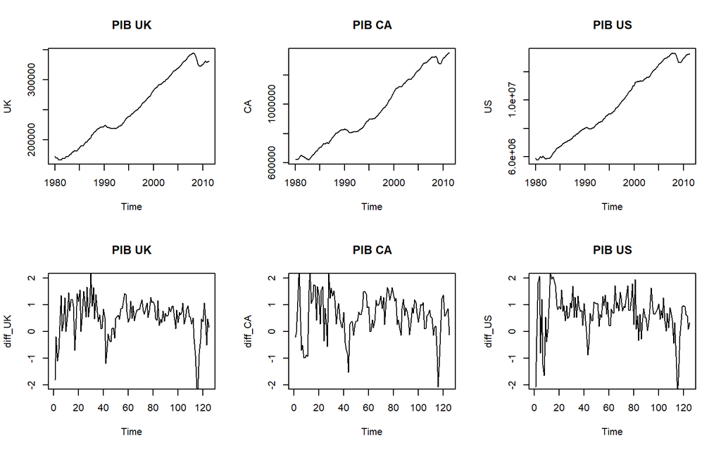

Les graphiques représentant les PIB de la Grande Bretagne, du Canada et des Etats-Unis, présentent une tendance générale croissante de 1980 à 2011. Ce pendant cette évolution est marqué par deux périodes de légères décroissance de 1990 à 1991 et de 2007 à 2008. La première décroissance est dûe à la [récession du début des années 1990](https://fr.wikipedia.org/wiki/R%C3%A9cession_du_d%C3%A9but_des_ann%C3%A9es_1990) qui a été une crisé économique mondiale résultant de l’effondrement du Dow Jones Industrial. La deuxième décroissance est dûe à la [crise des subprimes](https://fr.wikipedia.org/wiki/Crise_des_subprimes), une crise financière qui a touché le secteur des prêts hypothécaires dans le monde entier.  
Etant donné que ces séries présentent une tendance, elle ne peuvent pas être stationnaire. Pour stationnariser ces processus, nous les avons différencié.  
Le gaphique des PIB différencié montre que les valeurs oscillent autour de 0. Elle semble donc stationnaire.

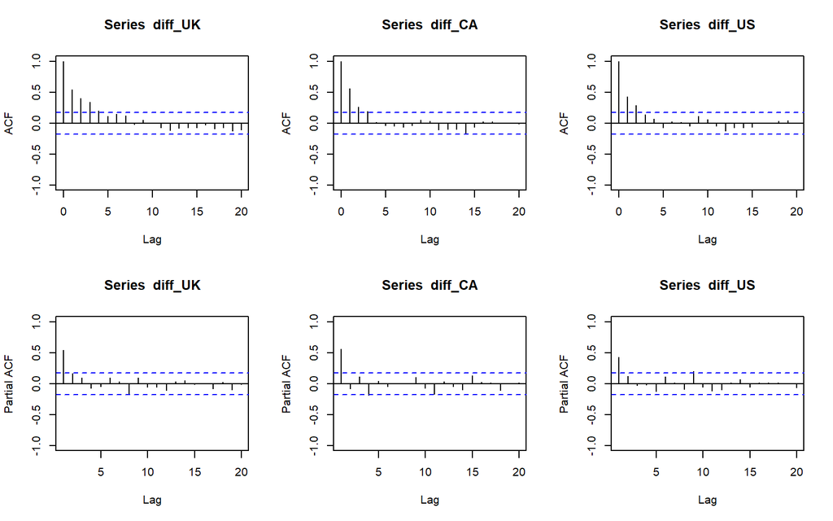

Le graphe des ACF (des séries différenciées) décroît (exponnetiellement) vers 0. Cela nous conforte dans notre conjecture. Enfin, le test augmenté de Dickey-Fuller nous permet de conclure que les séries différenciées sont stationnaires.On a donc un processus Intégré d’ordre 1 : $I(1)$.

Comme vu précédamment, le graphique des ACF présente une décroissance exponentielle vers 0. On en déduit que l’ordre q = 0 de la partie MA. Alors que le graphique des PACF des trois séries présente un seul pic significatif. On en déduit que l’ordre p = 1 pour la partie AR.

**Conclusison :** On identifie des processus $ARIMA(1,1,0)$. Par ailleurs, à travers une procédure automatique “$auto.arima()$”, le processus $ARIMA(1,1,0)$ est celui qui minimiser le “BIC”.

```
            ar1
t.stat 11.89054
p.val   0.00000
```

```
            ar1
t.stat 12.18657
p.val   0.00000
```

```
           ar1
t.stat 10.5491
p.val   0.0000
```

```
     Retard    p-value
[1,]      4 0.01629920
[2,]      8 0.01170874
[3,]     12 0.02960232
```

```
     Retard    p-value
[1,]      4 0.04418026
[2,]      8 0.12954394
[3,]     12 0.11086564
```

```
     Retard    p-value
[1,]      4 0.00880975
[2,]      8 0.00134008
[3,]     12 0.00165652
```

Toutefois, on peut considérer une autre approche pour modéliser ces valeurs de PIB. En effet le PIB de ces trois pays peut être considéré comme un vecteur de PIB. Dans ce cas, on utilise un modèle VAR. L’utilisation d’un tel modèle serait intéressant si la connaissance du PIB d’un pays améliore la prédivision du PIB d’un autre; c’est à dire qu’il y a de la causalité au sens de Granger.

```
Granger causality test

Model 1: diff_CA ~ Lags(diff_CA, 1:1) + Lags(diff_UK, 1:1)
Model 2: diff_CA ~ Lags(diff_CA, 1:1)
  Res.Df Df     F    Pr(>F)
1    124
2    125 -1 12.17 0.0006728 ***
---
Signif. codes:  0 '***' 0.001 '**' 0.01 '*' 0.05 '.' 0.1 ' ' 1
```

```
Granger causality test

Model 1: diff_CA ~ Lags(diff_CA, 1:1) + Lags(diff_US, 1:1)
Model 2: diff_CA ~ Lags(diff_CA, 1:1)
  Res.Df Df      F    Pr(>F)
1    124
2    125 -1 24.348 2.531e-06 ***
---
Signif. codes:  0 '***' 0.001 '**' 0.01 '*' 0.05 '.' 0.1 ' ' 1
```

### b. Modélisation VAR

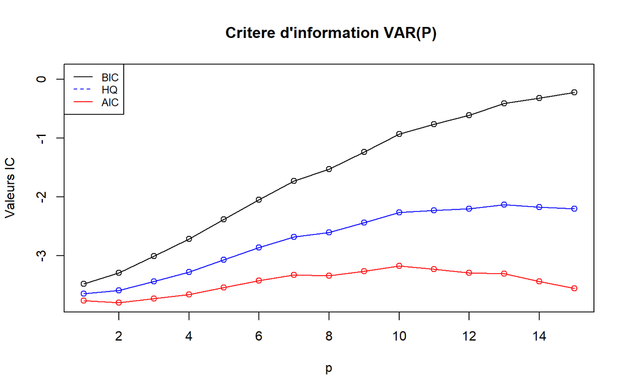

```
    Portmanteau Test (asymptotic)

data:  Residuals of VAR object var.1
Chi-squared = 90.286, df = 81, p-value = 0.225
```

Le BIC, le HQ sont minimisés pour une valeur de p = 1. On choisit un modèle VAR(1). Et les résidus de ce modèle sont bruits blancs (p-value = 0.225).

Ce pendant ce modèle a t-il une meilleure capacité prédictive que les 3 modèles ARIMA ? Pour répondre à cette question nous évaluons le pouvoir prédictif de ces deux approches sur les 4 dernières observations (nos données de validation), les modèles étant construits sur le reste des observations. Nous utilisons l’écart absolu moyen (MAE) pour challenger ces approches.

$$MAE = \Sigma_{i=1}^n | \hat{Y_i} - Y_i |$$

## 2 Prévisions des modèles

Les graphiques ci-dessous présentent la prévisions des PIB du Royaume-Uni (UK), du Canada(CA) et des Etats-Unis (US) entre 2010 et 2011. L’analyse de ces graphiques montre que pour les PIB du Royaume-Uni et du Canada, les prévisions réalisés avec le processus VAR sont plus proches des valeurs observées que celles réalisées avec les processus ARIMA. Tandis que pour le PIB des USA, les prévions réalisées avec le processus VAR s’éloignent dratisquement des valeurs observées. On en déduit que pour la prévision du PIB du Royaume-Uni et du Canada, le processus VAR a une meilleure capacité prédictive que les modèles ARIMA. Mais pour la prévision du PIB des USA, les modèles ARIMA ont une meilleure capacité prédictive que le processus VAR.

[interactive chart not shown]

## 3 Performances à posteriori

```
MAE ARIMA =   7469.359  ET  MAE VAR =   55818.01
```

En moyenne le prévisions du modèle VAR(1) s’écartent beaucoup plus des valeurs observées que celles des processus ARIMA(1,1,0). Donc Les modèles ARIMA ont une meilleure capacité prédictive que le processus VAR(1). Ce résultat s’explique par l’écart important du processus VAR(1) pour la prévision du PIB des USA.

**Conclusion :** pour modéliser les PIB de la Grande Bretange, du Canada et des Etats-Unis, on a beaucoup plus intérêt à utiliser trois processus ARIMA(1,1,0) qu’un processus VAR(1).

# Exercice 4 Implémentation des modèles VAR, SVAR et SVEC.

Cette partie est réalisée par : Sidi TRAORE et Brice Camel TIFA

## Introduction

Depuis les années 1980 suite aux critiques de Sims relativement à l’hypothèse d’exongénéité des variables dans la modélisation de phénomènes macro-économiques, l’analyse des séries temporelles multivarirées dans le contexe des VAR (Vector Auto-Regressive) a beaucoup évolué et est devenu un instrument standard en économétrie. En effet, des tests statistisques sont utilisées pour déterminer l’inter-dépendance et la relation dynamique dans les variables. Cette méthodologie a été enrichie avec l’incorporation des informations à priori non statisques.

Les modèles VAR expliquent les variables endogènes uniquement par leur propre histoire, en dehors des régresseurs déterministes. En revanche, les modèles vectoriels autorégressifs structurels (SVAR) permettent l’explicitation la modélisation de l’interdépendance contemporaine entre les variables. Il tentent donc de contourner les défauts des modèles VAR. Cependant, qu’il s’agisse des modèles VAR ou SVAR, la stationarité de chaque variable est un prérequis à la modélisation.

Engle et Granger (1987) ont doté les économétriciens avec un outil puissant pour modéliser et tester les relations économiques, à savoir le concept de co-intégration. Aujourd’hui, ces branches de la recherche sont unifiées sous la forme des modèles de correction vectorielle des erreurs (VECM) et de correction vectorielle structurelle des erreurs (SVEC).

Dans ce travail, reproduirons les travaux de bernhard pfaff. Concrètement, nous présenterons les principaux concepts des modèles VAR, SVAR, VECM, SVEC et la mettrons en oeuvre ces derniers sur un jeu de données relatifs à la macroéconomie canadiènne.

### 1 Modèles VAR

#### 1.1 Cadre théorique

Un processus Vecteur Auto-Regressif d’ordre p, noté VAR(p) est spécifié comme suit :

$$\begin{equation}
y_t = A_1y_{t-1} + ... + A_p y_{t-p} + u_t
\end{equation}$$

Où les $A_i$, pour ${i = 1, ..., p}$, sont des coefficients d’une matrice de dimension $(K \times K)$ et les résidus $u_t$ sont bruits blancs. C’est à dire :

$$\mathbb{E}(u_t) = 0 \quad \mathrm{et} \quad \mathbb{E}(u_tu_t^T) = \Sigma_u$$
La matrice de variance-covariance des érreurs, $\Sigma_u$, est supposée indépendante du temps et définie positive.

On peut réecrire le modèle VAR comme suit :

$$y_t - A_1y_{t-1} - ... - A_p y_{t-p} = u_t \\
(I_K - A_1z - ... A_pz^p)y_t = u_t \\
\Phi(z)y_t = u_t \space$$
Tout processus VAR(p) peut être reécrit sous forme d’un processus VAR(1) en utilisant les notations suivantes:

$$\xi_t = A \xi_{t-1} + v_t$$
Avec :

$$\xi_t =
\left(\begin{array}{c}
y_t\\
.\\
.\\
.\\
y_{t-p+1}
\end{array}\right),
A =
\left(\begin{array}{ccccccc}
A_1 & A_2 &. &. &. & A_{p-1} &A_p \\
I &0 &. &. &. &0 &0 \\
0& I & . &. & . &0 &0 \\
.& . &. & & & . &. \\
.& . & &. & & . &. \\
.& . & & &. & . &. \\
0& 0 &. &. &. & I &0
\end{array}\right),
v_t =
\left(\begin{array}{c}
u_t\\
0\\
.\\
.\\
.\\
0
\end{array}\right)$$

Avec $\xi_t$ et $v_t$ des vecteurs de dimension $(KP \times 1)$ et $A$ une matrice de dimension $(KP \times KP)$.

Une caractéristique importante du processus VAR(p) est sa stabilité. Le processus $VAR(P)$ est stable si sa formulation VAR(1) est stable. Autrement dit, si toutes les valeurs propres de $A$ sont de module est inférieur à 1.

#### 1.2 Implémentation

$$y_t =
\left(\begin{array}{c}
prod_t\\
e_t\\
u_t\\
rw_t
\end{array}\right)$$
Les auteurs entament l’étude par une représentation graphique des séries.

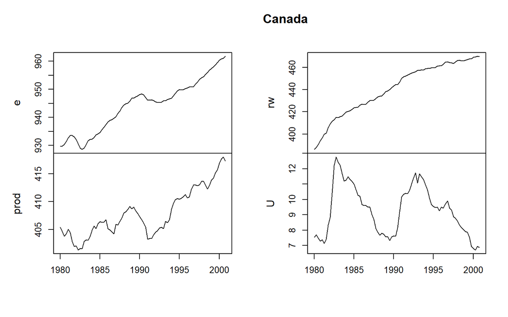

Le graphique ci-dessus permet de remarquer une tendance croissante pour le taux d’emploi (e), la productivité (prod) et l’indice du salaire (rw). Tandis que le taux de chômage (u) ne présente pas de tendance.

Point clé de la modélisation VAR, l’étude de la stationarité est ensuite mise en oeuvre.

**Stationnarité :**

La première étape pour les auteurs a consisté a effectué des test augmenté de Dickey-Fuller pour vérifier la stationnarité du processus VAR.

Les auteurs continue néanmoins la modélaisation VAR sur la série brute. Ils s’intéressent par la suite à l’ordre $p$ du modèle. Ils reprennent pour ce faire les travaux de Breitung et al. (2004).

**Sélection du modèle :**

Pour sélectionner le nombre de retard, les auteurs ont utilisé une procédure automatique, et recherché le nombre de retards qui minimise les critères d’informations AIC, FPE, HQ et SC.

```
AIC(n)  HQ(n)  SC(n) FPE(n)
     3      2      1      3
```

Selon l’AIC et la FPE, le nombre optimal de retards est p = 3, le HQ indique p = 2 et le critère SC indique un nombre optimale de retard p = 1.  
Ils ont estimé pour les trois ordres de retards, un VAR comprenant une constante et une tendance comme régresseurs déterministes. Pour valider le modèle, ils ont considéré le taux d’empoi (e) et ont effectué des tests sur les résidus de ce processus.

$$e_t = e_{t-1} + u_{t-1} + r w_{t-1} + \epsilon_t$$
Pour $p=1$ par exemple,

**Validation / Tests sur les résidus :**

Les auteurs effectuent un diagnostic des résidus pour les trois modèles VAR, ce en se basant sur les tests d’autocorrélations, le test ARCH multivarié et le test de Juarque-Berra.

[figure not shown]

Parmi les modèles considérés, les résidus du modèle VAR(1) sont bruits blancs (p-value =$0.606>5\%$, test de Portemanteau) et suivent une loi normale (p-value = 0.2708 pour le test de Jacque Berra). Par contre le test d’hétéroscédasticité d’Engle ne nous permet pas d’accepter l’hypothèse d’homoscédasticité des résidus pour le processus VAR(1) (p-value = 0.01606).

Compte tenu des résultats des tests de diagnostic, les auteurs (Breitung et al.) ont conclu qu’une spécification VAR(1) pourrait être trop restrictive. Ils maintiennent toutefois les modèles VAR(2) et VAR(3) comme candidats au test de cointégration.

Dans la suite, les auteurs estiment un modèle VECM dans lequel une tendance déterministe a été incluse. Avant de présenter ce modèle VECM, nous allons présenter le modèle SVAR.

### 2 Structural vector autoregressive models SVAR

Le modèle SVAR est la forme généralisée du modèle VAR(P). Il se définit comme suit :

$$Ay_t = A_1^*y_{t-1} + ... + A_p^*y_{t-p} + B \epsilon_t$$
Pour la modélisation, les hypotèses suivantes sont formulées :
1 - Les résidus structurels $\epsilon_t$ sont bruit blanc. 2 - Les coeffecients structurels sont différents de ceux du modèle VAR(p).

La remarque que l’on peut faire sur la formulation de ce modèle est qu’elle est quasiment égale à celle d’un VAR quand $A=B=Id$ (abscence de corrélation temporelle ou d’effets simultanés entre les variables).

Un modèle SVAR peut être utilisé pour identifier les chocs et les retracer en utilisant l’IRA (Impulse Response Analysis) et/ou le FEVD (Forecast Error Variance Decomposition), ce en imposant des restrictions sur les matrices A et/ou B. Les auteurs évoquent en effet deux avantages du modèle SVAR par rapport au modèle VAR:

Le modèle SVAR aide à saisir les réponses des variables du système aux chocs structurels identifiés; Le modèle SVAR grâce à sa décomposition de la variance, permet d’évaluer la part moyenne d’un choc structurel donné dans la dynamique (variation) des variables.

Quelque soit les valeurs des matrices $A$ et $B$, le système résultant contient plus d’équations que d’inconnues etnécessit de faire des restrictions pour être identifiable.

Les paramètres du modèle sont estimés en minimisant la log-vraissemblance négative.

$$lnL_c(A,B) = - \frac{KT}{2}ln(2\pi) + \frac{T}{2}ln|A|^2 - \frac{T}{2}ln|B|^2 - \frac{T}{2}tr(A^T (B^{-1})^T B^{-1} A \Sigma_u)$$

### 3. Vector error correction models (VECM)

Lorsque les séries ne sont pas stationnaires mais cointégrées, les modèles vectoriels à correction d’erreur (VECM) permettent de spécifier des relations stables à long terme tout en analysant dans le même temps la dynamique de court terme des variables considérées.

Partant de l’équation du processus VAR, nous pouvons définir l’équation d’un processus VECM de la manière suivante :

$$\Delta y_t = \alpha \beta^T y_{t-p} + \Gamma_1 \Delta y_{t-1} + ... + \Gamma_{p-1} y_{t-p+1} + u_t$$
Avec :

$$\Gamma_i = - (I - A_1 - ... - A_i), \quad i = 1, ..., p-1$$
Et
$$\Pi = \alpha \beta^T = - (I - A_1 - ... - A_i)$$

### 4.Structural vector error correction (SVECM)

#### 4.1 Modèle

En reconsidérerant l’équation précédante du processus VECM. Comme pour le modèle SVAR, on peut appliquer un raisonnement analogue aux modèles SVEC, en particulier lorsque la représentation VAR de niveau équivalent du Le VECM est utilisé. Toutefois, les informations contenues dans les propriétés de cointégration ne sont donc pas utilisées pour identifier les restrictions sur les chocs structurels. De ce fait, les variables ne sont pas utilisées pour identifier les restrictions aux chocs structurels.

$$\Delta y_t = \alpha \beta^T y_{t-1} + \Gamma_1 \Delta y_{t-1}+ ... + \Gamma_{p-1} y_{t-p+1} + B \epsilon_t$$

où $u_t = B\epsilon_t$ et $\epsilon_t\sim\mathcal{N}(0, I_K)$

Le processus peut se mettre sous la forme de moyenne mobile comme suit:

$$y_t = \Xi\sum_{i=1}^tu_i + \sum_{j=0}^\infty\Xi_j^\star u_{t-j} + y_0^\star$$
C’est donc la somme d’une composante intégrée à l’ordre 1 et d’une composante stationaire. $\Xi$ désigne une matrice de rang $K-r$, avec r nombre de relations de cointégration stationaires.

### 4.2 Implémentation

```
SVEC Estimation Results:
========================

Call:
SVEC(x = vecm, LR = LR, SR = SR, r = 1, lrtest = FALSE, boot = TRUE,
    runs = 100)

Type: B-model
Sample size: 81
Log Likelihood: -161.838
Number of iterations: 11

Estimated contemporaneous impact matrix:
         prod        e         U      rw
prod  0.58402  0.07434 -0.152578 0.06900
e    -0.12029  0.26144 -0.155096 0.08978
U     0.02526 -0.26720  0.005488 0.04982
rw    0.11170  0.00000  0.483771 0.48791

Estimated standard errors for impact matrix:
        prod       e       U      rw
prod 0.08531 0.11638 0.22511 0.07633
e    0.06977 0.05717 0.18840 0.04234
U    0.05815 0.04026 0.05249 0.03100
rw   0.14341 0.00000 0.65879 0.08452

Estimated long run impact matrix:
        prod       e       U rw
prod  0.7910  0.0000  0.0000  0
e     0.2024  0.5769 -0.4923  0
U    -0.1592 -0.3409  0.1408  0
rw   -0.1535  0.5961 -0.2495  0

Estimated standard errors for long-run matrix:
       prod      e      U rw
prod 0.1421 0.0000 0.0000  0
e    0.2003 0.1820 0.5802  0
U    0.1012 0.0896 0.1521  0
rw   0.1708 0.1569 0.2698  0

Covariance matrix of reduced form residuals (*100):
        prod      e       U     rw
prod 37.4642 -2.096 -0.2512  2.509
e    -2.0960 11.494 -6.9273 -4.467
U    -0.2512 -6.927  7.4544  2.978
rw    2.5087 -4.467  2.9783 48.457
```

Les auteurs ont cherché à savoir si les chocs de l’offre de travail n’ont pas d’impact à long terme sur le chômage ($\Xi B_{33}=0$) et effectué un test LR à cet affet.

```
    LR overidentification

data:  vecm
Chi^2 = 6.0745, df = 1, p-value = 0.01371
```

L’hypothèse nulle selon laquelle les chocs sur l’offre de travail n’exercent pas un effet à long terme sur le chômage est rejetée pour un niveau de signification de $5\%$.

Afin d’étudier les effets dynamiques sur le chômage, les auteurs ont appliqué une analyse de réponse impulsionnelle.

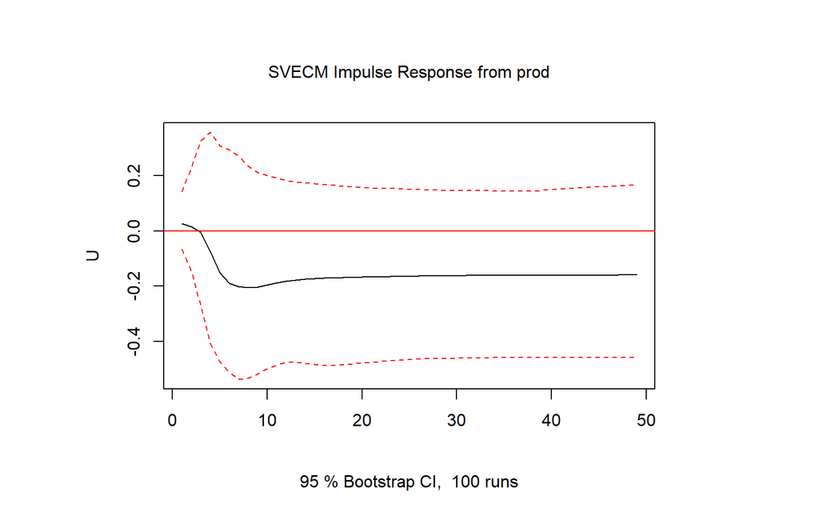

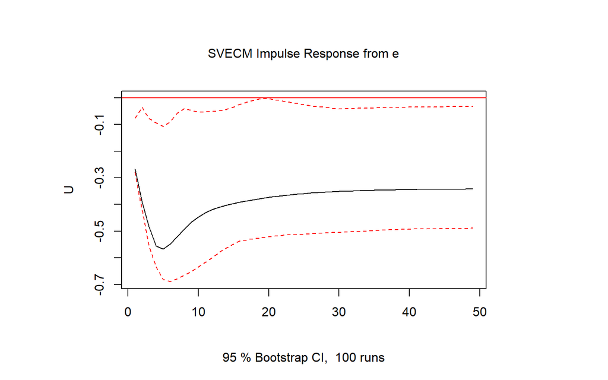

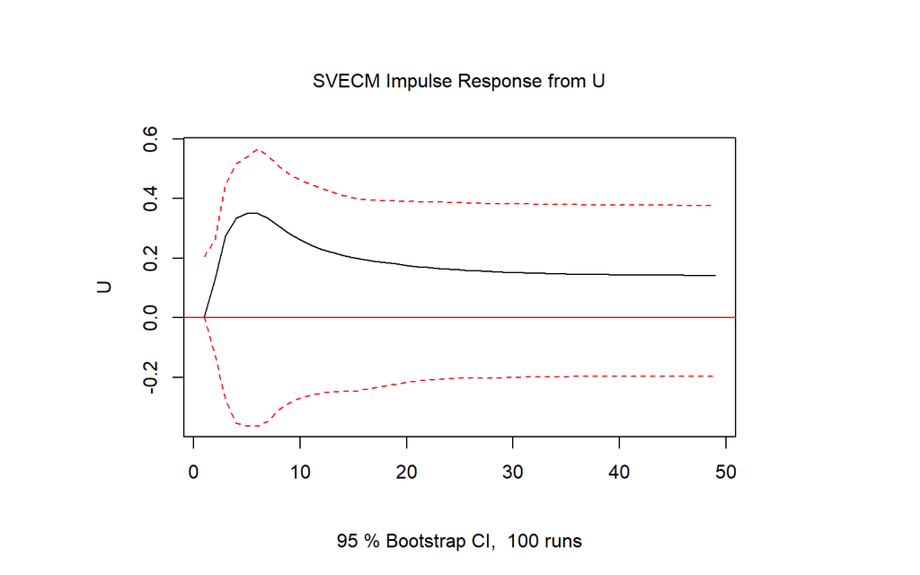

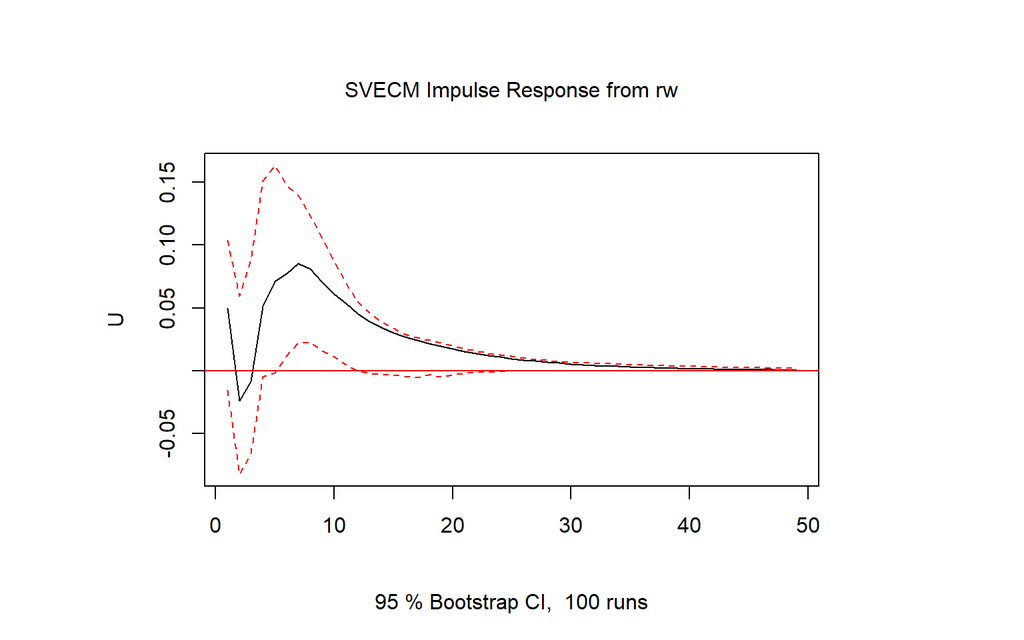

L’analyse de la réponse impulsionnelle montre les effets des différents chocs, c’est-à-dire la production, la demande de travail, l’offre de travail et le salaire, au chômage.

# Annexe

## 1. Test de blancheur (Test de Ljung-Box)

Hypothèses :
$$\begin{array}{l}
H_0 : \forall h \in [|1,...,k|] : \rho(h) = 0\\
H_1 : \forall h \in [|1,...,k|] : \rho(h) \ne 0
\end{array}$$
La statistique du test est $Q^*_k = T(T+2)\sum^k_{h=1}\frac{\hat{\rho}^2(h)}{T-h}$

## 2. Test de Stationnarité :Test augmenté de Dickey-Fuller (ADF)

Hypothèses :

**H_0 :** Y_t est un processus intégré d’ordre 1 au minimum $\Leftrightarrow$ Présence de racine unitaire (Y_t non stationnaire)

**H_1 :** Y_t est un processus AR(P) $\Leftrightarrow$ Pas de présence de racine unitaire (Y_t stationnaire)